# Casos de Covid-19 nos Estados Unidos da América

João José Lopes Cheixo (PG49837) Márcia Filipa Gonçalves Oliveira (PG49841) Mariana Rochinha Braguês (PG49843)

2023-01-20

### **Exercício prático de Métodos Estatísticos para a Bioinformática**

#### Introdução:

Deparado com o impacto global da COVID-19 e para uma melhor compreensão do mesmo, foi desenvolvido um estudo estatístico, utilizando o programa *RStudio* em linguagem R. Para isso, foram recolhidos dados na base “*Google dataset search*”.

Posto isto, os dados recolhidos correspondem aos diversos estados pertencentes aos Estados Unidos da América (EUA), nomeadamente, ao número de infetados e de mortes associados à Covid-19, ao número total de habitantes, assim como, a média de idades dos mesmos. Estes dizem respeito ao dia 11/01/2023.

Este estudo estatístico visa encontrar relações entre a taxa de mortes com a taxa de infetados e/ou a idade da população dos EUA.

#### Variáveis:

- **Estados** - variável qualitativa que categoriza os diferentes estados dos EUA;
- **Taxa de infetados** (Número de casos de infetados dividido pelo número total de habitantes de cada estado) - variável quantitativa contínua que corresponde aos casos confirmados de Covid-19 para cada estado;
- **Taxa de mortes** (Número de mortes dividido pelo número total de habitantes de cada estado) - variável quantitativa contínua que corresponde aos casos de óbito por Covid-19;
- **Idade** - variável quantitativa contínua que corresponde à idade média dos habitantes de cada estado.

#### Análise exploratória das variáveis:

Importação e respetiva leitura do ficheiro ‘covid’.

```r
covid=read.csv('covid.csv') #leitura de dados
```

Estados dos EUA.

```r
estado = covid$Estado
estado
```

```
##  [1] "NewHampshire"       "NewJersey"          "NewMexico"
##  [4] "NewYork"            "NorthCarolina"      "NorthDakota"
##  [7] "Ohio"               "Oklahoma"           "Oregon"
## [10] "Pennsylvania"       "RhodeIsland"        "SouthCarolina"
## [13] "SouthDakota"        "Tennessee"          "Texas"
## [16] "Wyoming"            "Utah"               "Vermont"
## [19] "Virginia"           "Alabama"            "Alaska"
## [22] "Arizona"            "Arkansas"           "California"
## [25] "Colorado"           "Connecticut"        "Delaware"
## [28] "DistrictofColumbia" "Florida"            "Georgia"
## [31] "Hawaii"             "Washington"         "Idaho"
## [34] "Illinois"           "Indiana"            "Iowa"
## [37] "WestVirginia"       "Kansas"             "Kentucky"
## [40] "Louisiana"          "Maine"              "Maryland"
## [43] "Massachusetts"      "Michigan"           "Minnesota"
## [46] "Wisconsin"          "Mississippi"        "Missouri"
## [49] "Montana"            "Nebraska"           "Nevada"
```

Valores da taxa de infetados por Covid-19 nos EUA.

```r
taxa_infetados = (covid$Infetados)/(covid$Populacao)
taxa_infetados
```

```
##  [1] 0.2664478 0.3516281 0.3637049 0.3489721 0.2750651 0.4377017 0.2925590
##  [8] 0.3638942 0.2753613 0.2795589 0.4275473 0.4466420 0.3608255 0.4180861
## [15] 0.3910131 0.3713886 0.4824351 0.2444619 0.3150205 0.3569121 0.4826744
## [22] 0.4647617 0.3702600 0.3509795 0.4045639 0.2808201 0.4123928 0.3051416
## [29] 0.4598926 0.3557073 0.3008393 0.3205229 0.3963428 0.3211271 0.3308800
## [36] 0.3036803 0.3477773 0.3421808 0.4143592 0.3403918 0.2418577 0.2511848
## [43] 0.3412824 0.3017670 0.3540235 0.3672862 0.3377991 0.3135446 0.3593580
## [50] 0.3262123 0.4384411
```

Valores da taxa de mortes por Covid-19 nos EUA.

```r
taxa_mortes = (covid$Mortes)/(covid$Populacao)
taxa_mortes
```

```
##  [1] 0.002072714 0.004236691 0.004881680 0.004125375 0.002367423 0.003860168
##  [7] 0.003627983 0.004663754 0.002638979 0.003999575 0.003643929 0.004869876
## [13] 0.004165099 0.004975144 0.004454767 0.003985564 0.002331216 0.001299220
## [19] 0.003242488 0.004781318 0.002245858 0.006297665 0.004764345 0.002993743
## [25] 0.003242072 0.003481948 0.004106687 0.002466529 0.005266801 0.004894794
## [31] 0.001454351 0.002574599 0.004122252 0.003280944 0.004188811 0.003576159
## [37] 0.004351495 0.003687671 0.004409950 0.004115932 0.002221311 0.003048059
## [43] 0.003637840 0.004120162 0.002918398 0.002975572 0.004620942 0.004189654
## [49] 0.004034604 0.002855201 0.005963697
```

Valores da média de idades da população por estado.

```r
idade = covid$Media_Idades
idade
```

```
##  [1] 37.1 36.7 34.6 35.9 35.3 36.2 36.2 35.5 36.3 38.0 36.7 35.4 35.6 35.9 32.3
## [16] 36.2 27.1 37.7 35.7 35.8 32.4 34.2 36.0 33.3 34.3 37.4 36.0 34.6 38.7 33.4
## [31] 36.2 35.3 33.2 34.7 35.2 36.6 38.9 35.2 35.9 34.0 38.6 36.0 36.5 35.5 35.4
## [46] 36.0 33.8 36.1 37.5 35.3 35.0
```

### Estatística descritiva das variáveis

**Variável taxa_infetados:**

```r
mean(taxa_infetados)                 #média
```

```
## [1] 0.3530839
```

```r
median(taxa_infetados)               #mediana
```

```
## [1] 0.3509795
```

```r
min(taxa_infetados)                  #mínimo
```

```
## [1] 0.2418577
```

```r
max(taxa_infetados)                  #máximo
```

```
## [1] 0.4826744
```

```r
diff(range(taxa_infetados))          #amplitude
```

```
## [1] 0.2408166
```

```r
sd(taxa_infetados)                   #desvio-padrão
```

```
## [1] 0.06170635
```

```r
var(taxa_infetados)                  #variância
```

```
## [1] 0.003807674
```

```r
fivenum(taxa_infetados)              #resumo de 5 números
```

```
## [1] 0.2418577 0.3093431 0.3509795 0.3936780 0.4826744
```

```r
summary(taxa_infetados)              #resumo de 5 números
```

```
##    Min. 1st Qu.  Median    Mean 3rd Qu.    Max.
##  0.2419  0.3093  0.3510  0.3531  0.3937  0.4827
```

```r
IQR(taxa_infetados)                  #distância interquartílica
```

```
## [1] 0.08433489
```

Representação gráfica da taxa de infetados

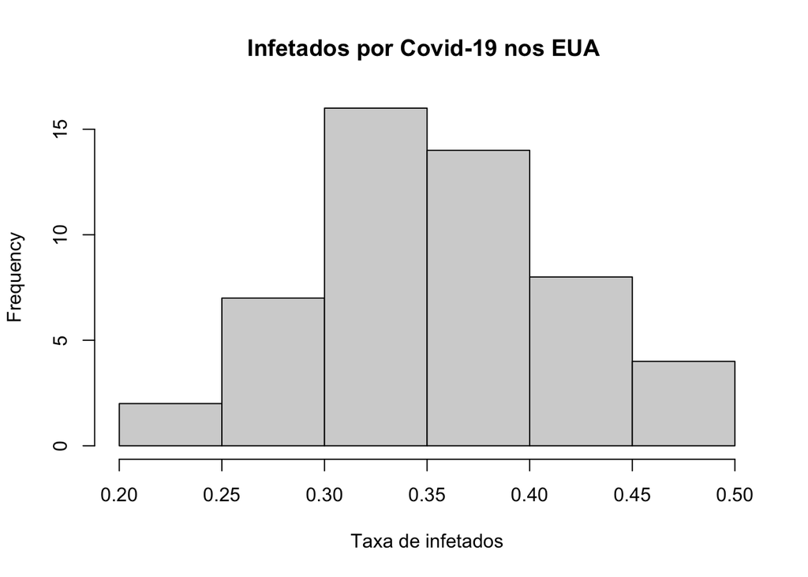

```r
hist(taxa_infetados, main="Infetados por Covid-19 nos EUA ",xlab="Taxa de infetados")
```

Caixa de bigodes da taxa de infetados

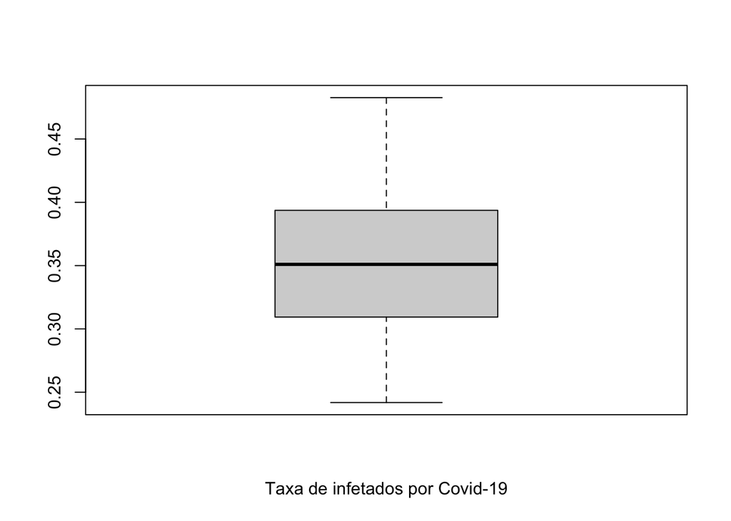

```r
boxplot(taxa_infetados,xlab="Taxa de infetados por Covid-19")
```

Relativamente ao histograma mencionado acima, é possível observar que a taxa de infetados mais frequente está contida entre os valores 0.30 e 0.35. A caixa de bigodes apresenta o primeiro quartil que é 0.31, a mediana igual a 0.35 e o terceiro quartil de 0.39.

**Variável taxa_mortes:**

```r
mean(taxa_mortes)                    #média
```

```
## [1] 0.003731981
```

```r
median(taxa_mortes)                  #mediana
```

```
## [1] 0.003985564
```

```r
min(taxa_mortes)                     #mínimo
```

```
## [1] 0.00129922
```

```r
max(taxa_mortes)                     #máximo
```

```
## [1] 0.006297665
```

```r
diff(range(taxa_mortes))             #amplitude
```

```
## [1] 0.004998445
```

```r
sd(taxa_mortes)                      #desvio-padrão
```

```
## [1] 0.001063942
```

```r
var(taxa_mortes)                     #variância
```

```
## [1] 1.131973e-06
```

```r
fivenum(taxa_mortes)                 #resumo de 5 números
```

```
## [1] 0.001299220 0.002984657 0.003985564 0.004380723 0.006297665
```

```r
summary(taxa_mortes)                 #resumo de 5 números
```

```
##     Min.  1st Qu.   Median     Mean  3rd Qu.     Max.
## 0.001299 0.002985 0.003986 0.003732 0.004381 0.006298
```

```r
IQR(taxa_mortes)                     #distância interquartílica
```

```
## [1] 0.001396065
```

Representação gráfica da taxa de mortes

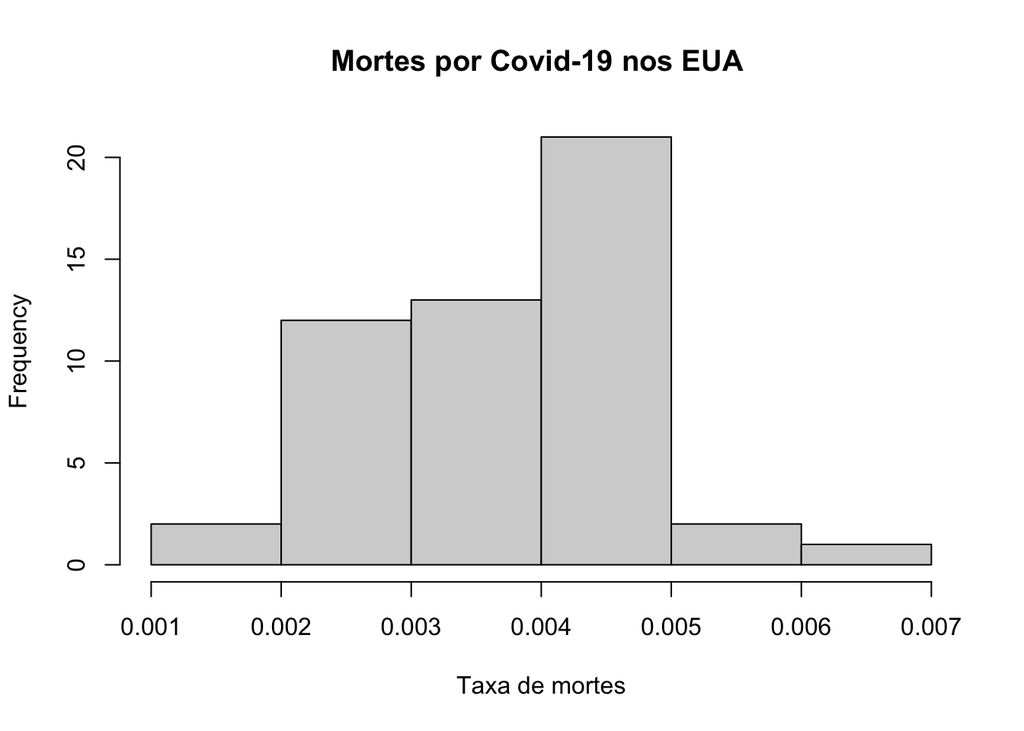

```r
hist(taxa_mortes, main="Mortes por Covid-19 nos EUA ",xlab="Taxa de mortes")
```

Caixa de bigodes da taxa de mortes

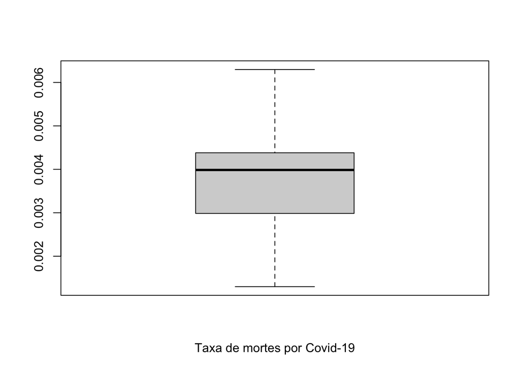

```r
boxplot(taxa_mortes,xlab="Taxa de mortes por Covid-19")
```

Relativamente ao histograma mencionado acima, é possível observar que a taxa de mortes mais frequente está contida entre os valores 0.004 e 0.005. A caixa de bigodes apresenta o primeiro quartil que é 0.003, a mediana igual a 0.004 e o terceiro quartil de 0.0044.

**Variável idade:**

```r
mean(idade)                            #média
```

```
## [1] 35.51765
```

```r
median(idade)                          #mediana
```

```
## [1] 35.8
```

```r
min(idade)                             #mínimo
```

```
## [1] 27.1
```

```r
max(idade)                             #máximo
```

```
## [1] 38.9
```

```r
diff(range(idade))                     #amplitude
```

```
## [1] 11.8
```

```r
sd(idade)                              #desvio-padrão
```

```
## [1] 1.888778
```

```r
var(idade)                             #variância
```

```
## [1] 3.567482
```

```r
fivenum(idade)                         #resumo de 5 números
```

```
## [1] 27.10 34.85 35.80 36.25 38.90
```

```r
summary(idade)                         #resumo de 5 números
```

```
##    Min. 1st Qu.  Median    Mean 3rd Qu.    Max.
##   27.10   34.85   35.80   35.52   36.25   38.90
```

```r
IQR(idade)                             #distância interquartílica
```

```
## [1] 1.4
```

Representação gráfica da média de idades

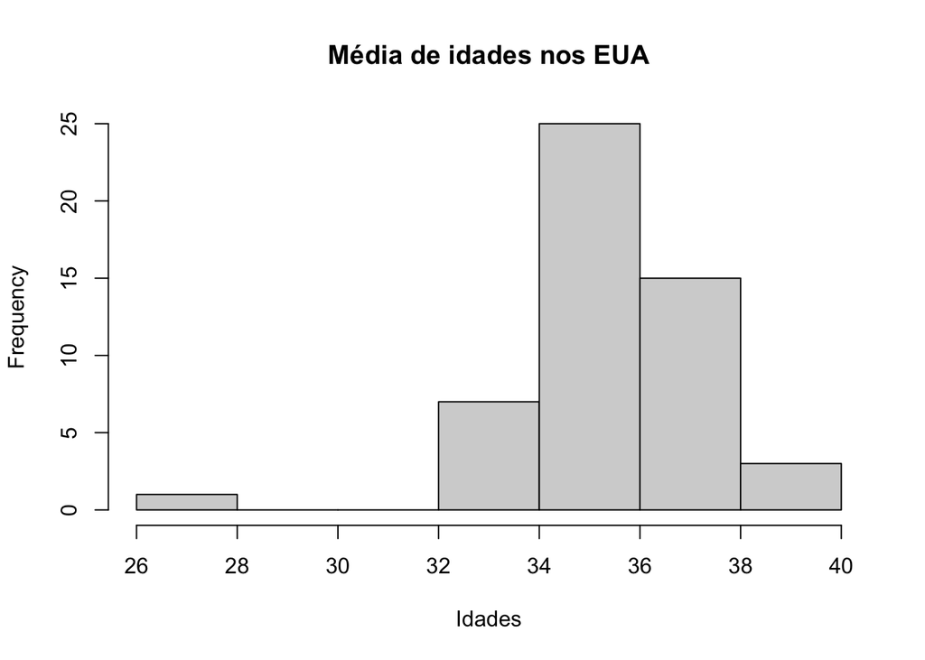

```r
hist(idade, main="Média de idades nos EUA",xlab="Idades")
```

Caixa de bigodes da média de idades

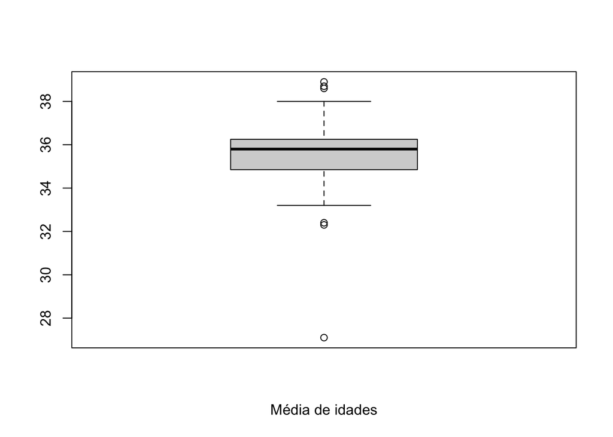

```r
boxplot(idade,xlab="Média de idades")
```

Relativamente ao histograma apresentado, é possível observar que a média de idades mais frequente está contida entre os valores 34 a 36 anos. A caixa de bigodes mostra o primeiro quartil que é 35, a mediana igual a 36 e o terceiro quartil de 36.3 anos. Além disso, consegue-se perceber a existência de vários “*outliers”*.

**Gráficos que relacionam as variáveis:**

Representação gráfica da taxa de infetados por estado

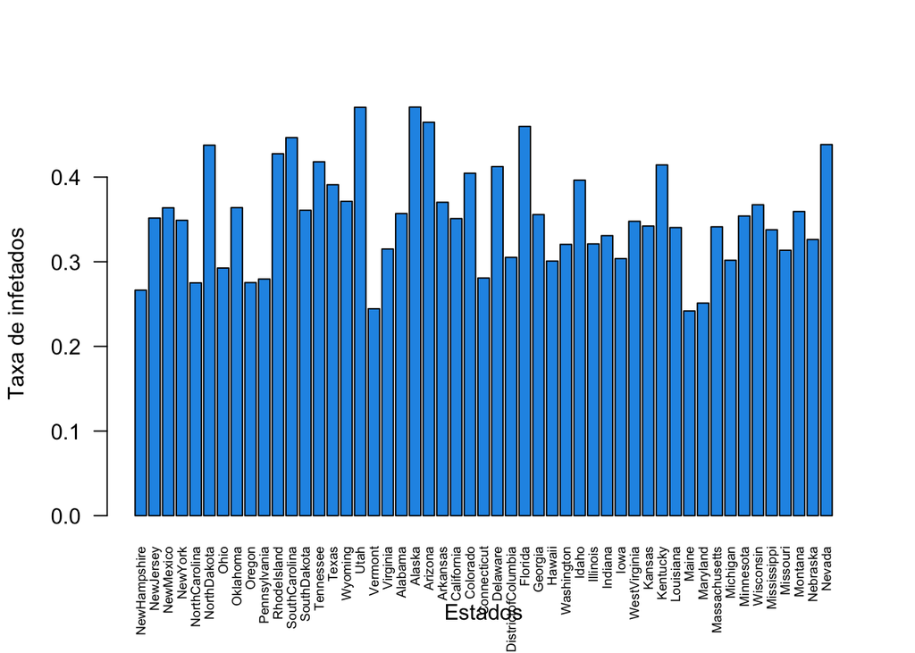

```r
barplot(taxa_infetados,names.arg=estado,
        xlab="Estados",ylab="Taxa de infetados", cex.names=0.6, las=2, col=c(4))
```

Representação gráfica da taxa de mortes por estado

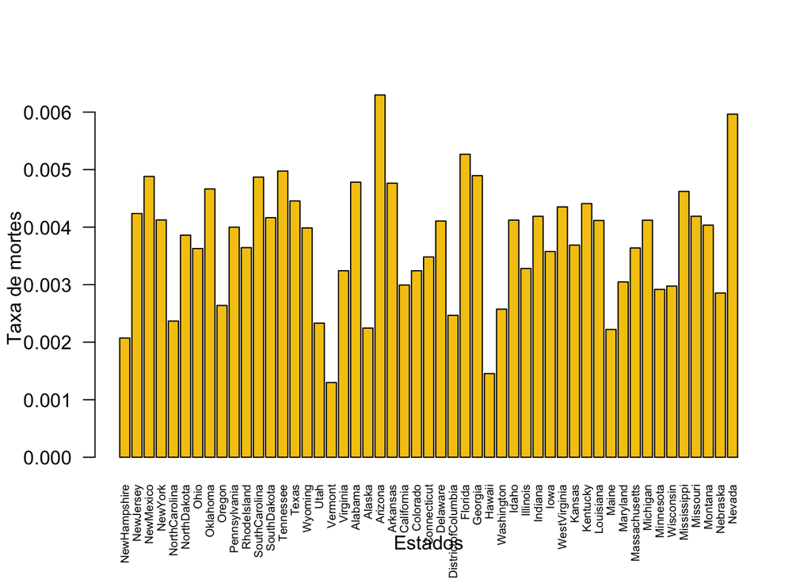

```r
barplot(taxa_mortes,names.arg=estado,
        xlab="Estados",ylab="Taxa de mortes", cex.names=0.6, las=2, col=c(7))
```

Representação gráfica da média de idades por estado

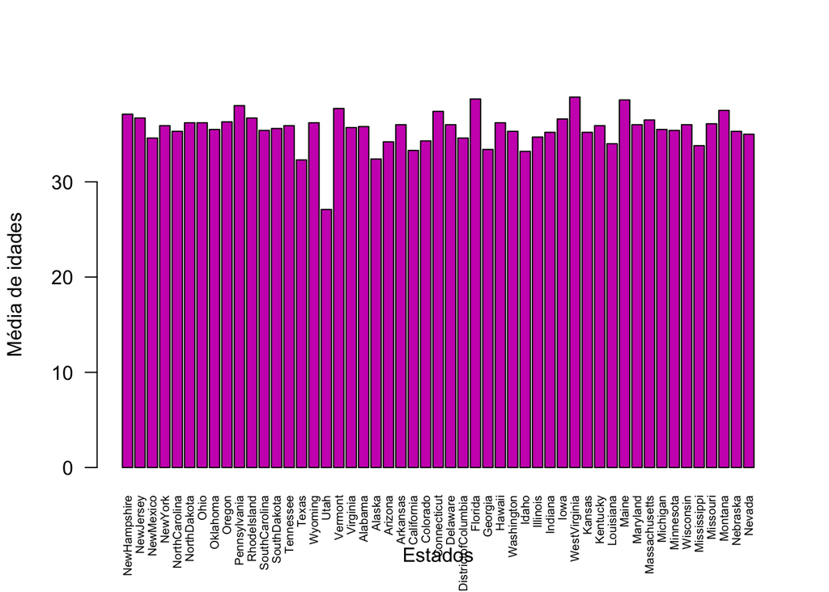

```r
barplot(idade,names.arg=estado, xlab="Estados",ylab="Média de idades", cex.names=0.6, las=2, col=c(6))
```

### Teste de normalidade das variáveis

**Variável taxa_infetados:**

H0: A variável taxa_infetados segue uma distribuição normal.

H1: A variável taxa_infetados não segue uma distribuição normal.

```r
shapiro.test(taxa_infetados)
```

```
##
##  Shapiro-Wilk normality test
##
## data:  taxa_infetados
## W = 0.97328, p-value = 0.3011
```

Após a realização do teste de normalidade *Shapiro-Wilk*, como o valor-p = 0.3011 que é superior ao valor de *alpha* (0.05), não se rejeita H0. Pelo que, considera-se que a variável taxa_infetados segue uma distribuição normal.

**Variável taxa_mortes:**

H0: A variável taxa_mortes segue uma distribuição normal.

H1: A variável taxa_mortes não segue uma distribuição normal.

```r
shapiro.test(taxa_mortes)
```

```
##
##  Shapiro-Wilk normality test
##
## data:  taxa_mortes
## W = 0.98346, p-value = 0.6923
```

Após a aplicação do teste de normalidade *Shapiro-Wilk,* como o valor-p = 0.6923 que é superior ao valor de *alpha* (0.05), não se rejeita H0. Pelo que, considera-se que a variável taxa_mortes segue uma distribuição normal.

**Variável idade:**

H0: A variável idade segue uma distribuição normal.

H1: A variável idade não segue uma distribuição normal.

```r
shapiro.test(idade)
```

```
##
##  Shapiro-Wilk normality test
##
## data:  idade
## W = 0.87263, p-value = 5.775e-05
```

Depois da realização do teste de normalidade *Shapiro-Wilk, c*omo o valor-p = 5.775e-05 que é inferior ao valor de *alpha* (0.05), rejeita-se H0. Sendo que, considera-se que a variável idade não segue uma distribuição normal.

### Testes de associações entre variáveis

**Variável taxa_infetados e variável taxa_mortes:**

H0: Não existe uma correlação signficativa entre a taxa de infetados e a taxa de mortes.

H1: Existe uma correlação signficativa entre a taxa de infetados e a taxa de mortes.

```r
cor(taxa_infetados,taxa_mortes)            #valor do coeficiente de correlação
```

```
## [1] 0.500033
```

```r
cor.test(taxa_infetados,taxa_mortes)       #teste de correlação
```

```
##
##  Pearson's product-moment correlation
##
## data:  taxa_infetados and taxa_mortes
## t = 4.0418, df = 49, p-value = 0.0001869
## alternative hypothesis: true correlation is not equal to 0
## 95 percent confidence interval:
##  0.2603219 0.6816805
## sample estimates:
##      cor
## 0.500033
```

Após a realização do teste de correlação *Pearson,* sendo o valor-p = 0.0001869 inferior ao valor de *alpha* (0.05), rejeita-se H0. Posto isto, pode inferir-se que a correlação entre as variáveis taxa_infetados e taxa_mortes é significativa.

Relativamente ao valor do coeficiente de correlação, como este é igual a 0.500033 (valor positivo) corresponde a uma associação positiva linear.

**Variável taxa_infetados e variável idade:**

H0: Não existe uma correlação signficativa entre a taxa de infetados e a idade.

H1: Existe uma correlação signficativa entre a taxa de infetados e a idade.

```r
cor.test(taxa_infetados,idade,method="spearman", exact=FALSE)    #teste de correlação
```

```
##
##  Spearman's rank correlation rho
##
## data:  taxa_infetados and idade
## S = 29735, p-value = 0.01303
## alternative hypothesis: true rho is not equal to 0
## sample estimates:
##        rho
## -0.3454616
```

Após a realização do teste de correlação *Spearman*, como o valor-p = 0.01303 que é inferior ao valor de *alpha* (0.05), rejeita-se H0. Sendo que, pode-se concluir que existe uma correlação significativa entre as variáveis taxa_infetados e a idade.

O valor de coeficiente de correlação é igual a -0.3454616 (valor negativo), existindo uma associação monótona negativa.

**Variável taxa_mortes e variável idade:**

H0: Não existe uma correlação signficativa entre a taxa de mortes e a idade.

H1: Existe uma correlação signficativa entre a taxa de mortes e a idade.

```r
cor.test(taxa_mortes,idade,method="spearman", exact=FALSE)       #teste de correlação
```

```
##
##  Spearman's rank correlation rho
##
## data:  taxa_mortes and idade
## S = 24743, p-value = 0.4032
## alternative hypothesis: true rho is not equal to 0
## sample estimates:
##        rho
## -0.1195916
```

Depois da aplicação do teste de correlação *Spearman*, como o valor-p = 0.4032 que é superior ao valor de *alpha* (0.05), não se rejeita H0. Pelo que, não existem evidências que não existe uma associação significativa entre a taxa_mortes e a idade.

### Modelo de regressão

A taxa_mortes vai corresponder a uma variável dependente, enquanto que a taxa_infetados e idade vão ser variáveis independentes (preditoras).

Gráfico de dispersão que relaciona a taxa de infetados com a taxa de mortes

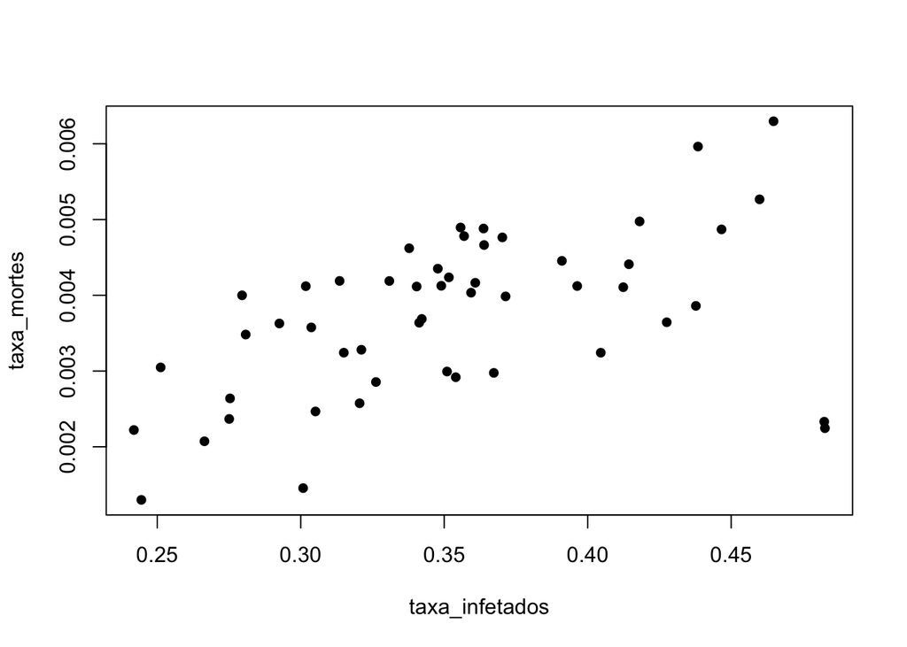

```r
plot(taxa_infetados,taxa_mortes,pch=16)     #gráfico de dispersão
```

Gráfico de dispersão que relaciona a idade com a taxa de mortes

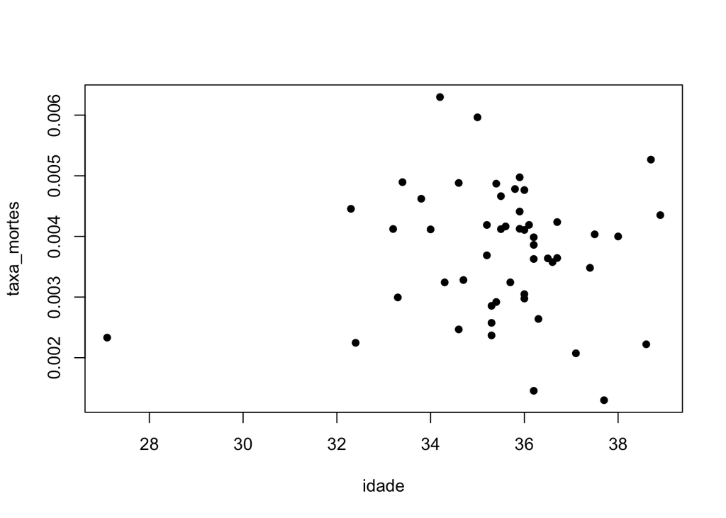

```r
plot(idade,taxa_mortes,pch=16)                       #gráfico de dispersão
```

Segundo o gráfico de dispersão que relaciona a taxa de infetados com a taxa de mortes, é possível observar que à medida que a taxa de infetados aumenta, a taxa de mortes também aumenta. Por outro lado, o gráfico que relaciona a idade com a taxa de mortes sugere que os valores da taxa de mortes concentram-se entre os valores de 34 e 38 anos.

**Modelo de regressão linear múltipla:**

Com o intuito de estudar a taxa de mortes em função da taxa de infetados e da idade, foi aplicado o modelo de regressão linear múltipla.

```r
model = lm(taxa_mortes ~ taxa_infetados+idade)        #coeficientes de regressão
summary(model)
```

```
##
## Call:
## lm(formula = taxa_mortes ~ taxa_infetados + idade)
##
## Residuals:
##        Min         1Q     Median         3Q        Max
## -0.0023742 -0.0005691  0.0001111  0.0007018  0.0015712
##
## Coefficients:
##                  Estimate Std. Error t value Pr(>|t|)
## (Intercept)    -6.055e-03  3.095e-03  -1.957   0.0562 .
## taxa_infetados  1.088e-02  2.284e-03   4.763  1.8e-05 ***
## idade           1.674e-04  7.463e-05   2.243   0.0295 *
## ---
## Signif. codes:  0 '***' 0.001 '**' 0.01 '*' 0.05 '.' 0.1 ' ' 1
##
## Residual standard error: 0.0008947 on 48 degrees of freedom
## Multiple R-squared:  0.3212, Adjusted R-squared:  0.2929
## F-statistic: 11.36 on 2 and 48 DF,  p-value: 9.162e-05
```

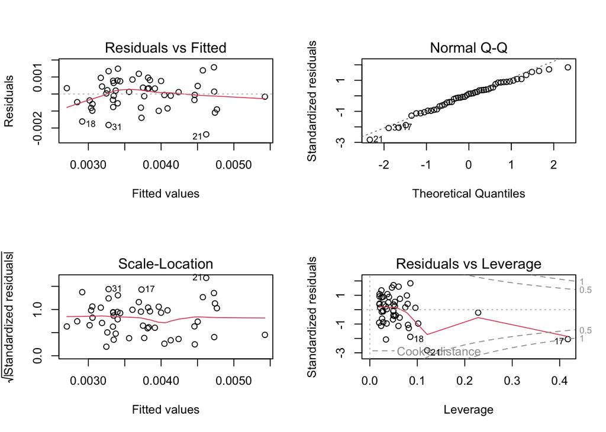

```r
par(mfrow=c(2,2))
plot(model)                                #gráficos de resíduos
```

A equação que traduz este modelo é y = 1.088e-02x1 + 1.674e-04x2 -6.055e-03, sendo:

- β0 = -6.055e-03
- β1x1 =1.088e-02, x1 é a variável taxa_infetados
- β2x2 = 1.674e-04, x2 é a variável idade

Teste ao declive:

H0: Não existe uma relação linear significativa entre a taxa de mortes e a taxa de infetados (β1 = 0).

H1: Existe uma relação linear significativa entre a taxa de mortes e a taxa de infetados (β1 ≠ 0).

Como o valor-p de β1 = 1.8e-0.5 é inferior ao valor de *alpha* (0.05), rejeita-se H0. Assim sendo, existe uma relação linear significativa entre a taxa de mortes e a taxa de infetados.

H0: Não existe uma relação linear significativa entre a taxa de mortes e a idade (β2 = 0).

H1: Existe uma relação linear significativa entre a taxa de mortes e a idade (β2 ≠ 0).

Como o valor-p de β2 = 0.0295 é inferior ao valor de *alpha* (0.05), rejeita-se H0. Assim sendo, existe uma relação linear significativa entre a taxa de mortes e a idade.

Coeficiente de determinação:

O coeficiente de determinação é igual a 0.3212, pelo que, a proporção de variabilidade da taxa de mortes explicada pelo modelo é de apenas 32.1%. O coeficiente de determinação ajustado é de 0.2929. O gráfico de resíduos apresentado acima indica que os resíduos não são aleatórios e não tem variância constante, sendo que, este modelo não se considera adequado.

Caso o modelo fosse adequado, poderia-se utilizar a equação obtida para prever a taxa de mortes.

Em seguida, segue-se um possível exemplo de uma previsão da taxa de mortes quando a taxa de infetados é 0.4 e a idade é 28 anos.

```r
predict(model, list(taxa_infetados=0.4, idade=28))        #previsão de valores
```

```
##           1
## 0.002983999
```

Como o modelo de regressão linear múltiplo apresentado anteriormente não era adequado, foi testado um modelo linear simples para estudar a taxa de mortes em função da taxa de infetados.

```r
model2 = lm(taxa_mortes ~ taxa_infetados)       #coeficientes de regressão
summary(model2)
```

```
##
## Call:
## lm(formula = taxa_mortes ~ taxa_infetados)
##
## Residuals:
##        Min         1Q     Median         3Q        Max
## -0.0026034 -0.0006685  0.0001946  0.0006568  0.0016029
##
## Coefficients:
##                 Estimate Std. Error t value Pr(>|t|)
## (Intercept)    0.0006878  0.0007644   0.900 0.372578
## taxa_infetados 0.0086216  0.0021331   4.042 0.000187 ***
## ---
## Signif. codes:  0 '***' 0.001 '**' 0.01 '*' 0.05 '.' 0.1 ' ' 1
##
## Residual standard error: 0.0009307 on 49 degrees of freedom
## Multiple R-squared:   0.25,  Adjusted R-squared:  0.2347
## F-statistic: 16.34 on 1 and 49 DF,  p-value: 0.0001869
```

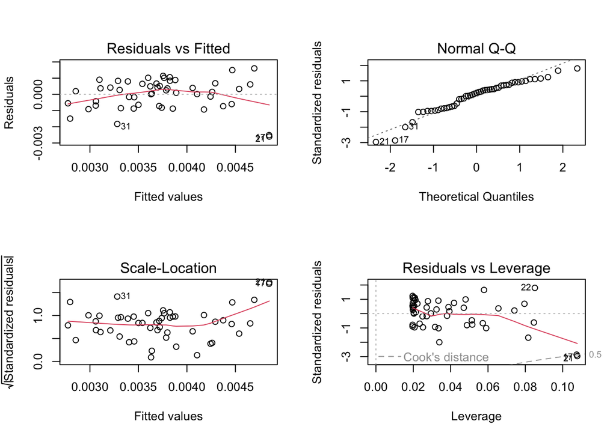

```r
par(mfrow=c(2,2))
plot(model2)
```

A equação que traduz este modelo é y = 0.0086216x + 0.0006878, sendo:

- β0 = 0.0006878
- β1 = 0.00862162

O coeficiente de determinação é igual a 0.25, pelo que, a proporção de variabilidade da taxa de mortes explicada pelo modelo é de apenas 25%. O coeficiente de determinação ajustado é de 0.2347. O gráfico de resíduos apresentado acima indica que os resíduos não são aleatórios e não tem variância constante, sendo que, este modelo não se considerado aplicado.

O coeficiente de determinação ajustado deste modelo linear simples (model2) é inferior ao coeficiente do modelo de regressão linear múltiplo, logo o model2 é ainda menos explicativo.

### Conclusão

Em suma, nos testes usados para estudar a associação entre variáveis taxa de infetados e taxa de mortes, assim como, taxa de infetados e idade, observou-se que existe uma correlação significativa entre elas. No entanto, não existem evidências que não exista uma associação significativa entre a taxa de mortes e a idade.

Relativamente aos modelos de regressão linear, pode-se concluir que nenhum dos dois modelos é adequado a estes dados. Outra possibilidade para desenvolver este estudo seria utilizar outros tipos de modelos.

Além disso, estes resultados podem ser justificados pela existência de fatores que não estão a ser tidos em conta, tais como, a possibilidade das mortes por Covid-19 não terem sido todas contabilizadas, ou as que foram não estarem associadas somente a esta infeção, registo erróneo dos casos confirmados, entre outros.